# GroupTrack — User Manual

### Finding a place

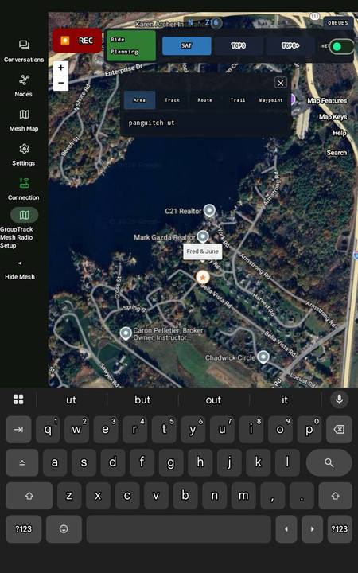

Type a place name.

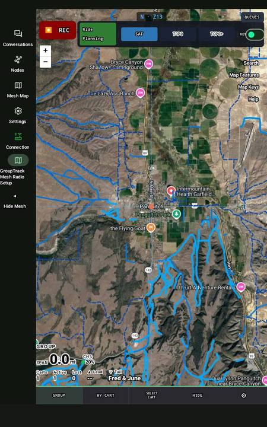

The map moves there.

**Qualify the name with its state** — "Panguitch UT". The same name exists in many states, and landing in the wrong one is not obvious: the map moves, trails draw, and everything looks right.

**Area search needs an internet connection.** Everything else — your tracks, trails, routes and waypoints — searches off grid.

**5.7 I · Map Featurestrails, tracks, routes, waypoints**

Turn any of the four on or off as a group. **SELECT** narrows to a single feature, or a combination you choose.

**Creating a ride** is done on the Ride Planning Map — tap a route or a track there: Map Features → ★ Create a Ride.

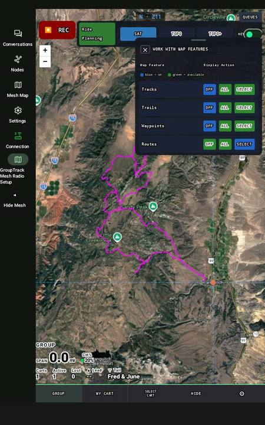

The panel.

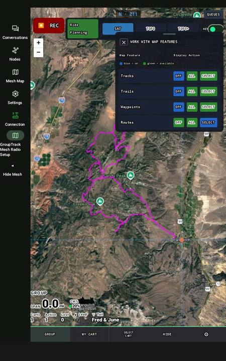

Off, all, or a selection.

### Working with trails on and off

Turn trails on while you are planning a route or recording your track — that is when you want them. Turn them off when you are looking at a larger area.

At any distance there are too many trails to be useful, and they **cover the map underneath** — town names, place names, the features you navigate by. Turning them off is often what makes an area readable.

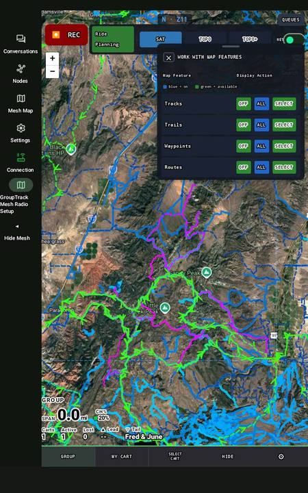

Everything on at once.

**5.7.1 SELECT on tracks, routes and waypointschoosing from a list**

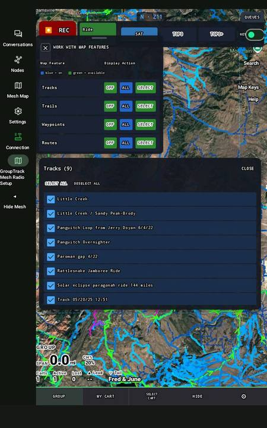

Pick from what is in view.

1. Press **SELECT** on the row you want.
2. A list appears of everything of that type in the current view.
3. Tap what you want drawn.

**Your choice persists** — it holds as you pan and comes back next time. The only thing that overrides it is a function that needs the map its own way, such as route comparison.

**5.7.2 SELECT on trailsnarrowing by category**

Trails work differently, and they have to. **There are 60,000 unnamed trails in Utah** — searching by name helps nobody.

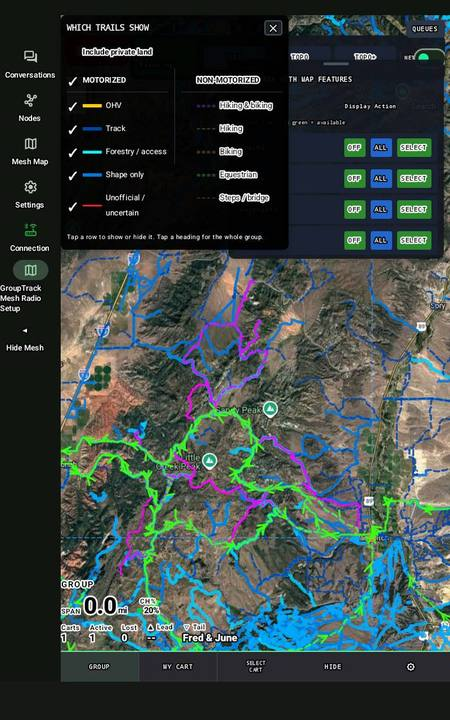

Narrow by category, not by name.

So you limit trails by **category** instead:

- **Private land** — include it or leave it out. Near a town, leaving it out removes the residential street grid.
- **Motorized and non-motorized** — take a whole group in or out.
- **Individual categories** — choose exactly which kinds you want.

**GroupTrack installs showing motorized trails on public land only.** If a trail you know exists is not on the map, that is usually why.

**5.8 J · Map Keyswhat the lines mean**

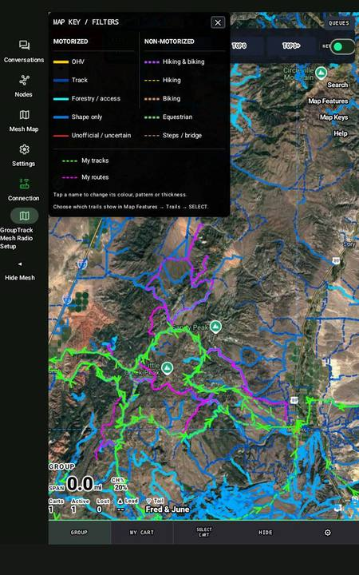

The legend.

GroupTrack installs with **solid lines for motorized trails** and **dashed lines for non-motorized**, with colours defined for each type. The legend tells you which is which.

**Every trail gets its category.** The last step of a state import, **Classify trails**, gives each trail its type, its use and its land — public or private — from the land-ownership record. It always runs: where there is no ownership data, the land counts as **public**, so trails show by default. A trail you expect but cannot see? Check Map Keys first — with **Land = Public**, roads classified as private are hidden by design — then Settings → Check a trail.

### What these mean

At the foot of the legend, **CATEGORIES EXPLAINED** opens this list:

[figure not shown]

Map Keys — what these mean.

| Type | What it is | Can you ride it? |
| --- | --- | --- |
| **OHV** | Posted trails for ATV/OHV use only | Yes |
| **Track** | Two wheel tracks, farm, forest or open country | Usually — unless posted |
| **Forestry / access** | Access unless posted otherwise | Yes, unless posted — look for a sign |
| **Shape only** | Shape and route of reported trails that are otherwise unclassified | Unknown — check the satellite imagery |
| **Rider trails** | Ridden on a recorded track — UTV accessible | Yes — a rider has been there |
| **Unofficial / uncertain** | Not available for riding | No |
| **Hiking & biking · Hiking · Biking · Equestrian** | Non-motorized trails | No |
| **Steps / bridge** | Stairs and footbridges | No — not rideable |
| **My tracks** | Rides you have recorded on this device | Yours |
| **My routes** | Routes you have planned or been sent | Yours |

Motorized types are drawn as solid lines, non-motorized as dashed; the legend shows each colour. Non-motorized types are off by default — switch them on in Map Features.

**5.8.1 Changing how something is drawncolour, pattern, thickness**

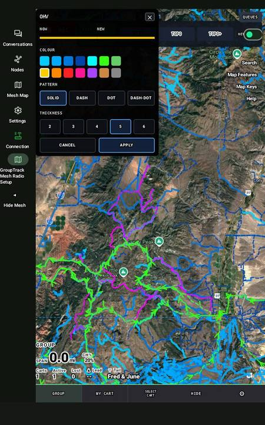

Tap the name, not the swatch.

1. Tap the **name** of the item in the legend.
2. Choose a colour, a line pattern and a thickness.
3. The panel shows the line as it is beside the line as it would be.
4. **Apply** redraws the map. Your choice is kept.

Every item on the legend can be arranged to your own preference.

**5.9 K · Helpthe three documents**

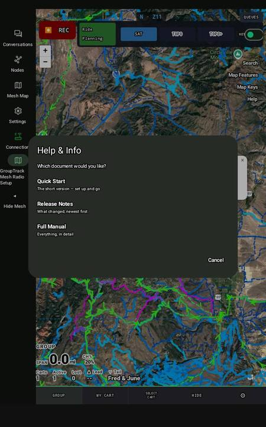

Three documents.

Both the Quick Start and the release notes **link into the matching section of this manual**, so you can go deeper wherever you want to.

All three work with no signal.

**5.10 L · GRP Awarenessyour radio in one place**

**GRP Awareness** sits where *Mesh* was, on both maps: white text on a **green** box when your radio is connected, a **red** box when it is not, and the box pulses as the group is heard. Tap it:

- **Connected to** — your radio's name, **DISCONNECT**, and **Last applied**: the ride (and date) last set up on it.
- Next release (2.7b): with **group awareness off** (Settings), the GRP Awareness box is **grey**; tapping it says group mode must be switched on in Settings — switch it on only when your radio is with you. The radio list shows your radios' **call signs at once**, before any scan or connection (it showed the radio's own *Meshtastic_xxxx* name until then).
- Next release (2.7b): under the radio's name, GroupTrack shows the network the **radio itself** is on: **GroupTrack network …** (green) when it is set up for GroupTrack, or **Not set up for GroupTrack** (amber) when it is on another network. The line under it is this tablet's record for that radio: **Last applied here** (ride and date) or **Not applied from this tablet before** — a guest's radio set up on another tablet still shows as set up.
- **Available radios** — the radios your tablet can see. **CONNECT** one. A radio marked *New to this Android* needs **PAIR** first (the code is **1234** unless your radio came with its own). **FORGET** a radio that has stopped connecting: GroupTrack and Android both let go of it, so you can pair it again cleanly. **ADD A RADIO** opens Android's Bluetooth settings.
- **Select a ride and apply settings to the radio** — the radio setup screen (Setting up your radio); this is how you set up **a guest's radio** under their own callsign.
- **Radio settings** — ⚠ for experienced mesh operators only: opens the app's own radio settings. **BACK TO MAP** (or Android's back button) returns you to the map. (Planned: Saved configs takes this button's place, and the Meshtastic side menu becomes the only Meshtastic function here — CFGHOME.)
- **Meshtastic side menu** — the full Meshtastic menu, for anything not here yet.
- Next release (2.7b): the Meshtastic side menu (and the left-hand rail of Meshtastic icons) is **gone**. In its place GRP Awareness has **NODES** — *radios heard*: the list of radios your radio has heard. It opens on top of the map like **Radio settings**, and **BACK TO MAP** (or Android's back button) returns you to the map — from a radio's own page too.

Pressing **✔ CHK IN › REC** with no radio connected opens GRP Awareness with *"Connect your radio to check in"*; once your radio connects, the check-in opens by itself.

[figure not shown]

GRP Awareness — the radio you are connected to, and when it was last set up.

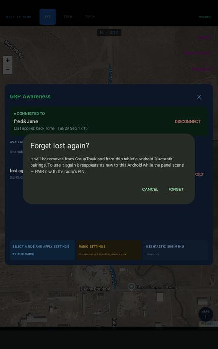

FORGET asks first — it removes the pairing from GroupTrack and from Android.

**Your radio isn't answering (2.7b, 18 October):** if nothing at all is heard from your radio for 30 seconds while riding with a group, the red banner says **"Your radio isn't answering. Check it is powered on."** — 15 seconds later GroupTrack reconnects by itself and keeps trying. After three failed tries the banner gives the FORGET / PAIR advice below. A radio that only lost its GPS fix is **not** disconnected: your cart follows this tablet's GPS until the radio's fix returns.

**5.11 M · Settingspreferences, and your release level**

Next release (2.7b): **Group awareness** has its own switch at the top of its section. The settings that act on other carts — **Signal Drop**, **Signal Lost**, **Off Track** (from the lead's track), **Admission Window** and the new **Show lead track** (draws or hides the lead cart's track on the ride map) — show **only while group awareness is on**. **Removed:** Multicolor track, Lead Cart Only, the KML / GPX recording switch (tracks are always GPX) and Removed Carts (use **Select Carts** to put a cart back). Your alert values are now **kept after a restart** (they used to go back to the built-in values).

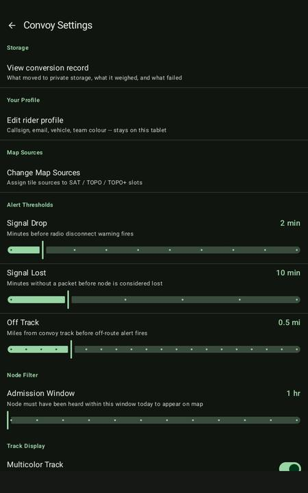

Settings.

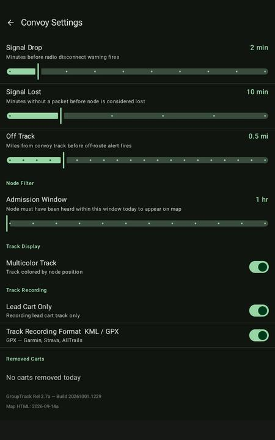

Continued.

The list of things you can customise — your map sources, how long error messages stay up, and so on. Most are self-explanatory.

### Remove all trail data

**Settings → Storage → Remove all trail data** removes every trail and its details, so trails can be imported again from a clean start. **Your tracks, routes, waypoints and downloaded maps stay.** It asks first, shows that it is working, and says what it removed; it waits while a trail import is running. Then import again: **Import Trails by State**, and **ADD TRAILS FROM TRACKS**. Use it when support asks you to.

### Check a trail

**Settings → Check a trail**: type a trail's id. GroupTrack shows what it holds for that trail and whether — and why — the map draws it. **SEND** emails the result to support. Use it when a trail you expect is not on your map; support tells you which id to check.

**Your release level is at the bottom left of this panel.** That is the number to quote if you report a problem.

**5.12 N · HIDEunclutter the map**

[figure not shown]

Before.

[figure not shown]

After.

**5.13 O · VIEW CART ROLESwho is checked in; remove, activate, change my role**

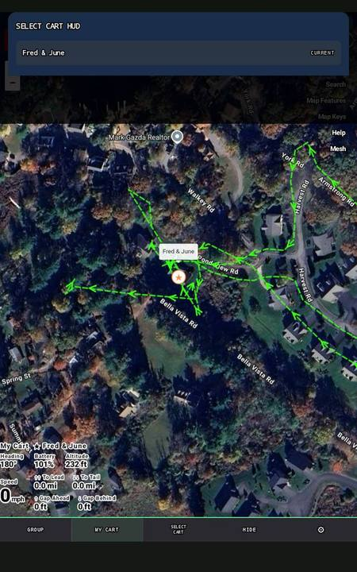

The carts in your group.

The button on the bottom bar reads **VIEW CART ROLES** and opens the **CART ROLES** panel: every cart on your ride, special roles first, each with a green **✔** (checked in) or a red **●** (not yet). Check in from the **CHK IN** button at the top left; before you do, the panel says *"Not checked in yet — tap CHECK IN at the top left to choose your ride."*

**Tap a cart:** your own cart, once you have checked in, opens **Change my role** — and afterwards returns here showing your new role. Any other cart: *"You can only change the role of …"* your connected radio — each tablet changes only its own cart's role.

Two other things you can do:

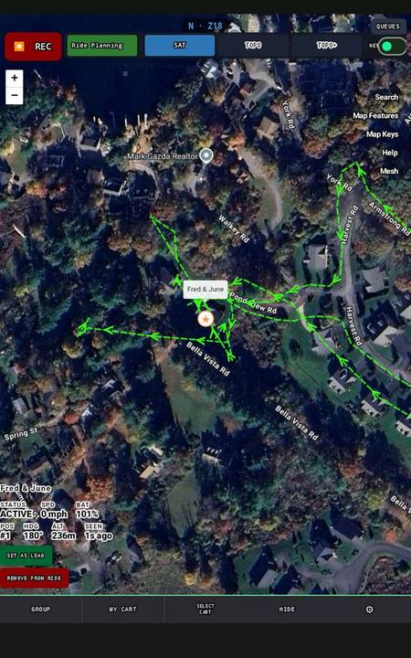

Remove a cart, or make it the lead.

### Remove a cart

A breakdown, or someone heading home early. Removing them takes them out of your tracking so the readout stops counting a rider who is no longer on the ride.

### The lead cart

The lead and tail follow the riders who hold the **Leader** and **Tail gunner** roles. When riders swap, they change their roles at a stop (Roles on the trail).

Next release (2.7b): when nobody holds Leader there is no lead; two riders claiming the same role are both set back to Rider. The full rules: Roles on the trail.

**5.13.1 Remove and activate a cartnew in 2.7a**

📷 NEW IMAGE NEEDED — SELECT CART is now VIEW CART ROLES / CART ROLES (10-06 release)

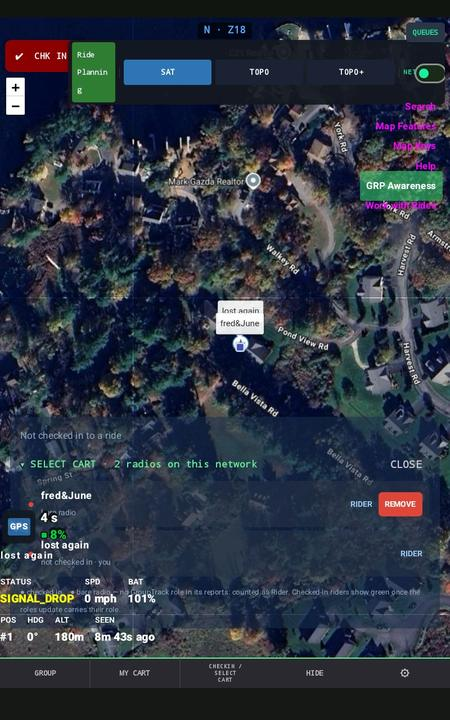

SELECT CART — pick a cart to follow.

Every other cart in the list has **REMOVE**: it leaves the map and the group on this tablet. A removed cart shows **ACTIVATE** to bring it back. **END** sets every cart back to Active. (SET AS LEAD and REMOVE FROM RIDE are no longer on the cart detail.)

**5.13.2 Change my rolenew in 2.7a**

📷 IMAGE TO CHECK — Change my role now returns to VIEW CART ROLES showing the new role; other carts show "You can only change the role of …" (10-06 release)

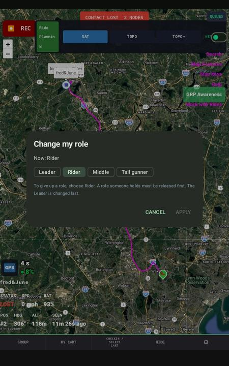

Change my role.

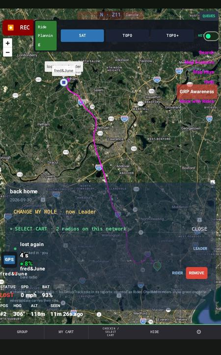

The new role shows on the map.

**Change my role** changes your own role only, and only to a role no other cart holds.

**5.14 P · MY CARTback to you, and follows you**

📷 IMAGE TO CHECK — HUD text colours now follow the HUD text switch (10-06 release)

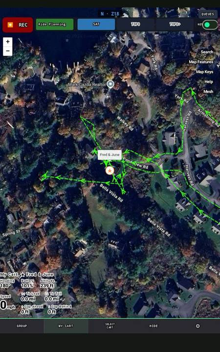

You, centred.

Wherever you have panned to, MY CART brings you **straight back to your own location at zoom 18** — and then follows you, panning the map to keep you in the centre as you ride.

📷 IMAGE TO CHECK — HUD text colours now follow the HUD text switch (10-06 release)

[figure not shown]

This is the one to press after searching somewhere else.

Next release (2.7b): your cart on your own map always follows **this tablet's GPS**, each time it moves — with your radio connected too (on a ride it could stay put on your own tablet while the radio was connected). The other riders see you from your radio.

**5.15 Q, R · GROUP, and the readouta wider view, or the whole group**

Next release (2.7b): with group awareness off, **GROUP** is greyed and the HUD stays on **MY CART**; tapping GROUP explains how to switch group awareness on.

📷 IMAGE TO CHECK — HUD text colours now follow the HUD text switch (10-06 release)

[figure not shown]

The group view.

### Riding alone

GROUP gives you a **zoom 16 vantage point** — more of the trail ahead, while keeping your cart centred.

### Riding with radios

It shows **every member of the group**, scaling the map so every cart fits. Front to back, with the gaps between them.

### The readout

The display at the bottom left follows whichever you have selected — GROUP or MY CART.

- **SPAN** — from the lead cart to the last.
- **Carts**, **Active** and **Lost** — how many are in the group, how many are reporting, and how many have stopped.
- **Lead** and **Tail** — the front and back of the ride.

### Tapping a cart

Next release (2.7b): tap another cart to open its details. They update with each report from that cart. **SPD** its speed, **ALT** its altitude in feet, and **GAP** — the time between that cart's last two reports (it replaces SEEN). A GAP that keeps growing means that radio is getting hard to hear.

**5.16 S · Zoomin and out**

In and out. The map also pinches, and MY CART and GROUP set a zoom for you.

**5.17 T · GPShow often your location is sent**

Next release (2.7b): with group awareness off, the GPS row is dimmed and the GPS button explains how to switch group awareness on — the interval is your radio's, so it only applies with a radio.

**On the ride map, above the HUD at the left edge:** the **GPS** button (a satellite), and beside it two numbers:

- **How often your radio sends your location while moving** — for example **6 s**. Standing still, it sends every 30 seconds.
- **How busy the radio channel is**, in **green** (plenty of room), **yellow** (getting busy) or **red** (congested).

**Tap GPS** to change it: the window shows the current value, the channel use and the number of carts. Key in **3 to 10 seconds** and tap **APPLY**. Your radio is set **once**, then disconnects and reconnects by itself (about half a minute) — the window shows each step. **CANCEL** changes nothing.

**Beside them, the HUD text switch** — a circle, half white and half black — switches the readouts' text between white and dark: one setting for GROUP, MY CART and the selected cart, remembered for each map type during the session. White suits SAT; dark suits TOPO.

**When to change it:** green — leave it. **Yellow — send less often** (a higher number) to free the channel. Red — the channel is congested; lengthen the interval and let the group know. Checking in sets your radio back to the ride's standard value.

📷 NEW IMAGE NEEDED — the HUD text switch (half-white/half-black circle) now sits beside GPS and the channel meter (10-06 release)

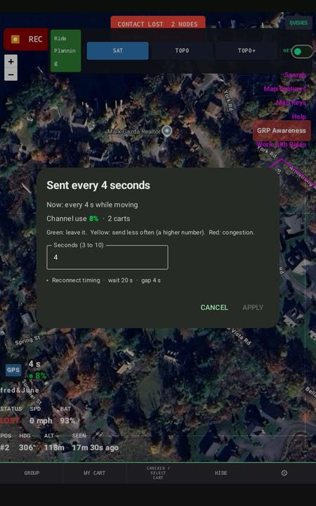

GPS — how often your position is sent.

**5.17.1 Reconnect timingnew in 2.7a**

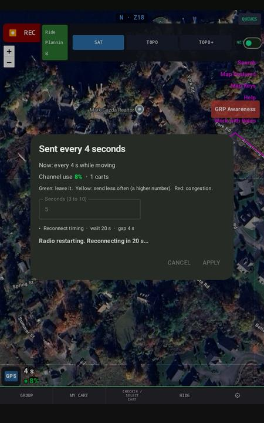

Applying a new interval restarts the radio.

After **APPLY** the radio restarts and GroupTrack reconnects to it — twice; the second reconnect waits 20 seconds. If a cart does not reappear, open **Reconnect timing** and raise the wait and the gap.

**5.18 U · Work with Ridesrides — share, edit, delete; import; apply to your radio; archive configs**

**Each letter has a heading underneath, and each heading opens** — that option in full: the screens it leads to, in the order you meet them.

**5.18.1 A · Rides — share, edit, delete**

**The Rides list.** Every ride on your tablet, newest first — the ones you created and the ones you received. The chips along the top filter them: **All**, or one person who created rides (your own name included). Tap a ride, then:

- **Send** — emails the ride.
- **Edit** — your own rides only. Opens the ride form **filled in**. Before it is sent, everything but the route and the network can change; once sent, **only the date** (the form says so) — send it again after saving. A new date also restarts its 30 days.
- **Delete** — any ride, after you confirm: *"The ride file, its record and its radio config are removed. Radio backups made for this ride are kept."* The route is never deleted.

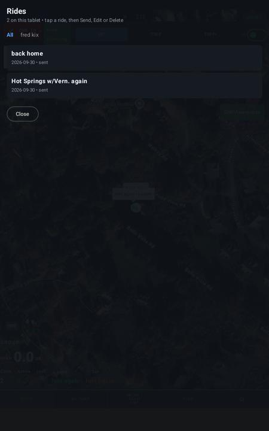

Rides — the rides on this tablet.

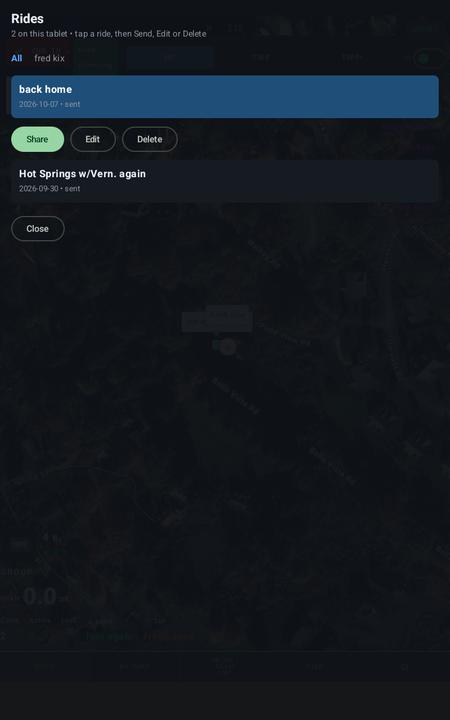

Tap a ride: Share, Edit or Delete.

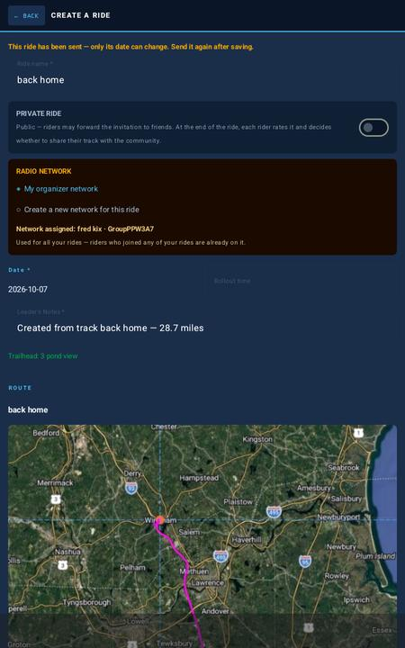

Editing a sent ride — only its date can change.

📷 NEW IMAGE NEEDED — the invite changed: HTML invite, attachment named after the ride, a download line (10-03 release)

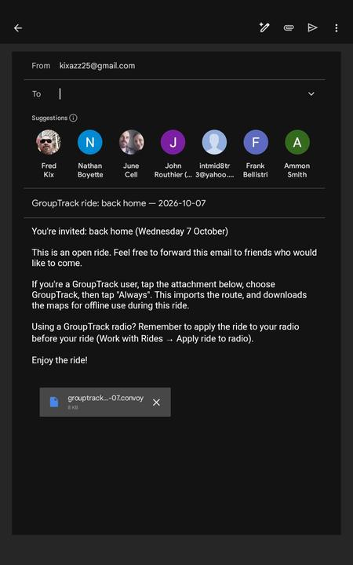

Share — the invite, ready to send.

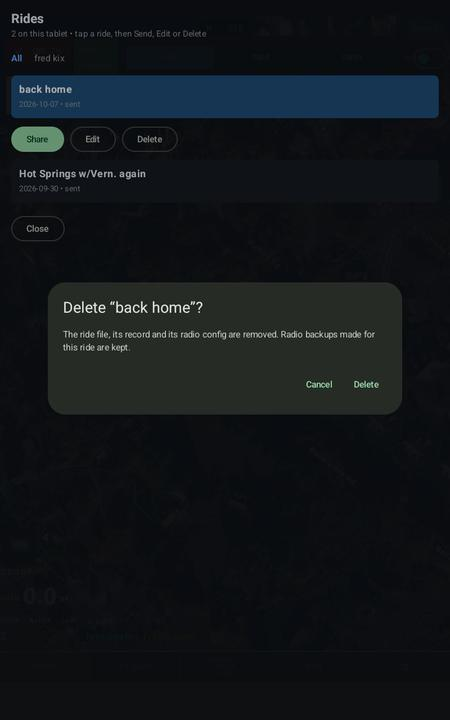

Delete asks first.

**Rides tidy themselves.** A ride is removed automatically **30 days after its date**. A ride you received always appears in the list, even if something about it was incomplete.